# Manipulacja osiami, a czytelność wykresów

Wiktor Woźniak

##### **Wprowadzenie**

W tej pracy sprawdzam jak manipulacje osiami wpływają na czytelność wykresów. W tym celu przygotowałem kilka wykresów opartych o dane sportowe. Zostały stworzone trzy wykresy słupkowe oraz trzy wykresy punktowe. Wykresy punktowe pokazywały miejsce sportowca lub zepołu w danym sezonie, natomiast wykresy słupkowe zliczały statystykę danego zawodnika lub zespoly w pewnym okresie lub w danym zespole. Manipulacje osiami polegały na zamianie osi x z y, odwrócenie osi x oraz odwrócenie osi y. Na każdym słupkowym i punktowym została wykonana jedna z manipulacji. Następnie każdy zmanipulowany wykres został połączony z jego niezmanipulowanym wykresem. W ten sposób powstało 6 par, które zostały umieszczone w ankiecie. Do każdej z tych par było jedno takie samo pytanie, “Który wykres jest dla Ciebie bardziej czytelny?”. Do wyboru była jedna z trzech odpowiedzi, “Prawy”, “Lewy”, “Tak samo czytelne”. Ankieta została wypełniona przez 31 osób, które nie posiadają wiedzy na temat tworzenia wizualizacji. W oparciu o uzyskane z niej wyniki przedstawiam poniższe wnioski.

Link do ankiety: https://forms.gle/WxXwNhWavFoK2kgv9

##### **Zamienianie osi miejscami**

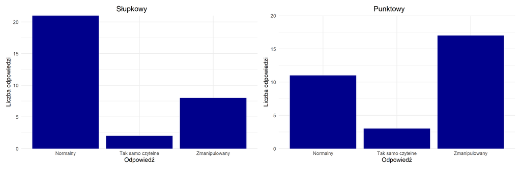

Wyniki w tej kategorii są dla mnie mocno zaskakujące. Po pierwsze jeśli chodzi o wykres słupkowy ankietowani zdecydowanie bardziej wolą podpisy na osi x, a zliczenie jakiejś wartości lub jej stosunek procentowy na osi y. Jest to dla mnie zaskakujące, ponieważ personalnie uważam, że akurat w tym przypadku nie ma znaczącej różnicy i spodziewałem się dużego udziału odpowiedzi, że oba wykresy są tak samo czytelne ale jak widać osoby odpowiadającę stwierdziły inaczej. Jeśli chodzi o wykres punktowy to tutaj ta różnica czytelności wykresów jest mniej znacząca. Jednakże, ludzie stwierdzili, że bardziej czytelne w momencie porównywania pozycji zawodniczek w danym sezonie gdy to miejsca są na osi x, a sezony na osi y. Naturalnym wyborem jednak wydawałoby się na odwrót, bo wtedy można łatwiej porównywać nie tylko pozycje między zawodniczkami, ale również jak wypada dana zawodniczka w danym okresie. Podsumowując ankitowani preferują, gdy wykresy słupkowe są pionowe, natomiast zamienienie osi miejscami na wykresie punktowych (gdy porównujemy pozycje danych osób na przestrzeni lat) wpływa pozytywnie na odbiór wizualizacji.

##### **Odwrócenie osi x**

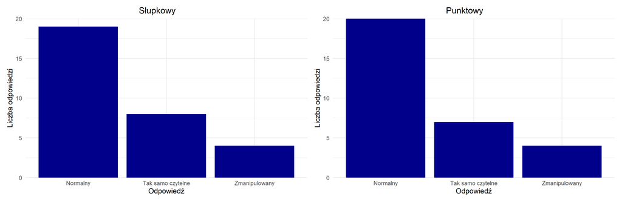

Co warto zauważyć jako pierwsze, przy odwracaniu osi x nie ma znaczenia rodzaj wykresu. Ludzie mówią stanowcze nie. Jest to o tyle zadowalające, ponieważ oznacza to, że ankietowani zauważają manipulacje jakie ciągnie ze sobą odwracanie osi. Po ich odpowiedziach widać, że mogą być świadomi tego, że odwrócenie osi x, niesie ze sobą często takie konsekwencje jak zmiana tendencji prezentowanych danych.

##### Słupkowy

| Odpowiedź | Liczba odpowiedzi |
| --- | --- |
| Normalny | 31 |
| Tak samo czytelne | 0 |
| Zmanipulowane | 0 |

##### Punktowy

| Odpowiedź | Liczba odpowiedzi |
| --- | --- |
| Normalny | 18 |
| Tak samo czytelne | 4 |
| Zmanipulowany | 9 |

Jeśli chodzi o odwrócenie osi y to wyniki są lekko zaskakujące. Jeśli chodzi o wykres słupkowy to wszyscy byli zgodni, że słupki zlatujące z powietrza wyglądają źle i są nieczytelne, więc nie ma co komentować w tym przypadku. Natomiast jeśli chodzi o wykres punktowy to tutaj odczuwam lekkie zaskoczenie. Na bardziej czytelny wykres został wybrany ten niezmanipulowany. Wydawaje mi się to dosyć ciekawe, ponieważ gdy porównujemy miejsca na koniec sezonu danych drużyn to wydawać by się mogło, że zwycięzca powinien być na samej górze, a kolejne miejsca pod nim. Jednakże, ankietowani zdecydowali, że wygodniej im się czyta wykres gdy oś y nie jest odwrócona przez co zwyciężcy są najbliżej osi x. Podsumowując, nie ma sensu odwracania osi y zarówno na wykresie słupkowym jak i punktowym, a zastosowanie takiego zabiegu w pierwszym przypadku może skończyć się tym, że wykarzemy się brakiem profesjonalizmu i wywołamy śmiech respondentów.

##### **Podsumowanie**

Patrząc na rozpatrzone przypadki manipulacja osiami na ogół zmniejsza czytelność wykresów. Ludzie wolą wykresy proste i nie ma sensu przekombinowywać w tej kwestii. Jeśli chodzi o mnie to przeprowadzenie tego badania wywołało u mnie kilka zaskoczeń i pokazało mi, że w porównaniu do mnie inni ludzi troche inaczej postrzegają wykresy.